# English 2016 D-Linking

Alex Kramer

4/10/2020

## English data

First, we load in the data.

```r
df.english <- read.delim("Eng16.txt")  %>% select(participant, list, order, condition, filler_type, response, zscore)

head(df.english, 50)
```

```
##    participant list order condition filler_type response     zscore
## 1           P1    1    10    FILLER         BAD        1 -1.2456356
## 2           P7    1    10    FILLER         BAD        2 -0.5764718
## 3          P13    1    10    FILLER         BAD        2 -1.1188107
## 4          P19    1    10    FILLER         BAD        1 -1.9197956
## 5          P25    1    10    FILLER         BAD        2 -0.7318200
## 6          P31    1    10    FILLER         BAD        1 -1.5589551
## 7          P37    1    10    FILLER         BAD        1 -0.9194239
## 8          P43    1    10    FILLER         BAD        2 -0.7396847
## 9          P49    1    10    FILLER         BAD        1 -0.9256433
## 10         P55    1    10    FILLER         BAD        1 -1.0198662
## 11          P2    2    59    FILLER         BAD        1 -0.8110363
## 12          P8    2    59    FILLER         BAD        1 -1.2811963
## 13         P14    2    59    FILLER         BAD        1 -1.3442019
## 14         P20    2    59    FILLER         BAD        2 -0.8189702
```

[output cut: 36 more lines]

Here we will be analyzing the D-linking experiment only, so we’ll create a couple of filtered dataframes. One for the D-linking data:

```r
# Get D-link items
dlink.conditions <- c("ShortBare", "ShortD", "ShortDOf", "LongBare", "LongD", "LongDOf")
df.english.dlink <- df.english %>% filter(condition %in% dlink.conditions)

# Reorder levels
df.english.dlink$condition <- factor(df.english.dlink$condition, levels = c("ShortBare", "ShortD", "ShortDOf", "LongBare", "LongD", "LongDOf"))

# Summary
df.english.dlink %>% group_by(condition) %>% summarize(count=n(), mean=mean(zscore), sd=sd(zscore), se=sd / sqrt(count)) %>% ungroup()
```

```
## # A tibble: 6 x 5
##   condition count  mean    sd     se
##   <fct>     <int> <dbl> <dbl>  <dbl>
## 1 ShortBare   224 0.942 0.619 0.0413
## 2 ShortD      224 0.907 0.703 0.0470
## 3 ShortDOf    224 0.917 0.650 0.0434
## 4 LongBare    224 0.742 0.731 0.0488
## 5 LongD       224 0.784 0.623 0.0416
## 6 LongDOf     224 0.853 0.527 0.0352
```

And one for fillers (just to take a look):

```r
# Get fillers, as well
df.english.filler <- df.english %>% filter(condition == "FILLER")
df.english.filler$filler_type <- factor(df.english.filler$filler_type, levels = c("GOOD", "BAD"))

# Summary
df.english.filler %>% group_by(filler_type) %>% summarize(count=n(), mean=mean(zscore), sd=sd(zscore), se=sd / sqrt(count)) %>% ungroup()
```

```
## # A tibble: 2 x 5
##   filler_type count   mean    sd     se
##   <fct>       <int>  <dbl> <dbl>  <dbl>
## 1 GOOD          280  1.04  0.633 0.0378
## 2 BAD          1512 -0.681 0.652 0.0168
```

## Histograms

First, we’ll make some histograms to vizualise the participants’ responses.

### Raw responses

#### D-linking items

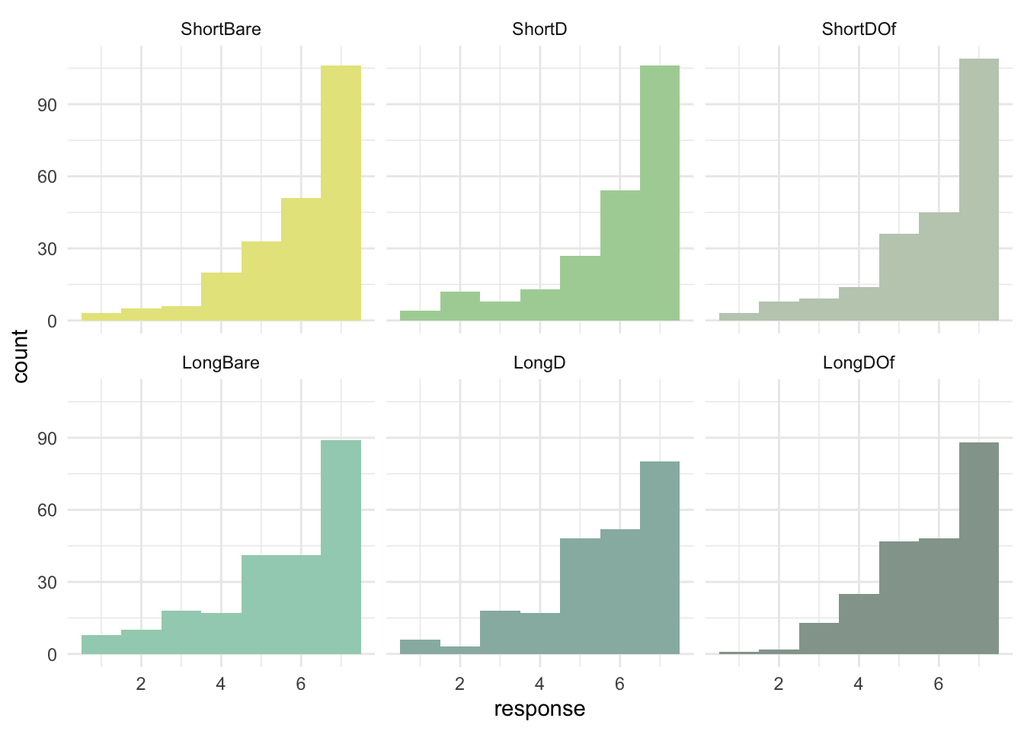

```r
ggplot(df.english.dlink, aes(response, fill=condition)) +
  scale_fill_ghibli_d("MarnieLight2", -1) +
  geom_histogram(binwidth = 1, show.legend=FALSE) +
  theme_minimal() +
  facet_wrap(.~condition)
```

#### Fillers

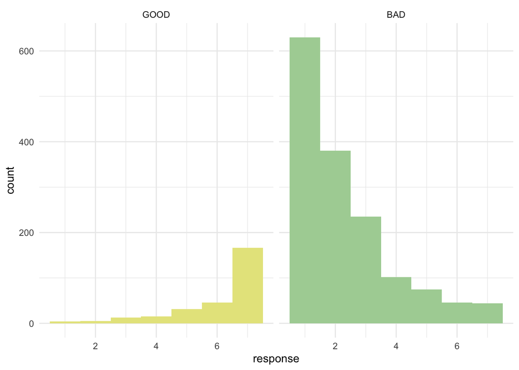

```r
ggplot(df.english.filler, aes(response, fill=filler_type)) +
  scale_fill_ghibli_d("MarnieLight2", -1) +
  geom_histogram(binwidth = 1, show.legend=FALSE) +
  theme_minimal() +
  facet_wrap(.~filler_type)
```

### Z-scored responses

#### D-linking items

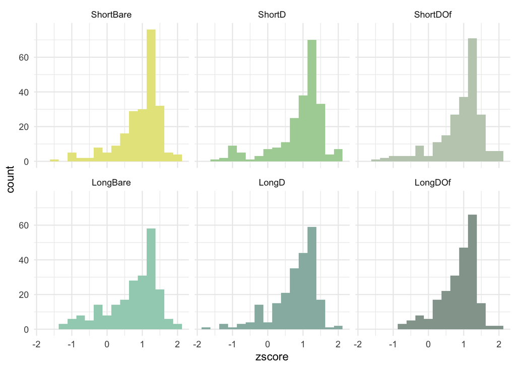

```r
ggplot(df.english.dlink, aes(zscore, fill=condition)) +
  scale_fill_ghibli_d("MarnieLight2", -1) +
  geom_histogram(binwidth = 0.25, show.legend=FALSE) +
  theme_minimal() +
  facet_wrap(.~condition)
```

#### Fillers

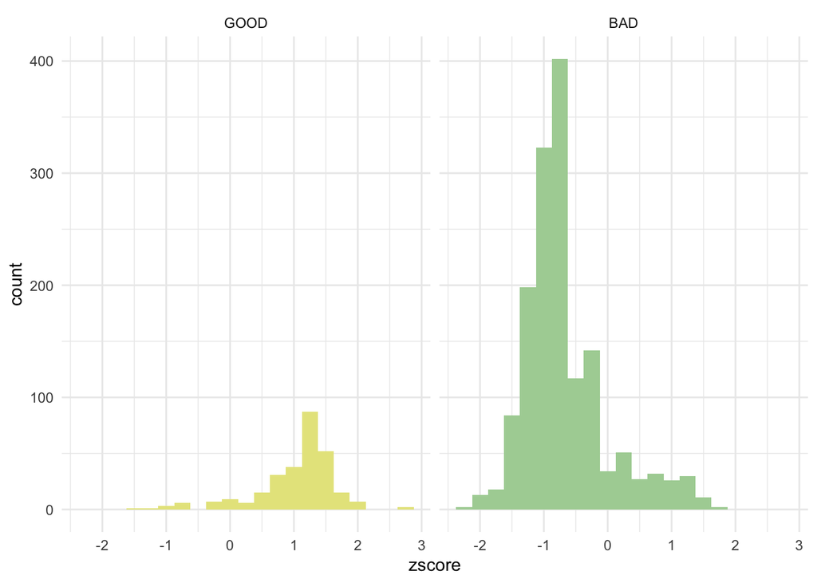

```r
ggplot(df.english.filler, aes(zscore, fill=filler_type)) +
  scale_fill_ghibli_d("MarnieLight2", -1) +
  geom_histogram(binwidth = 0.25, show.legend=FALSE) +
  theme_minimal() +
  facet_wrap(.~filler_type)
```

## Density plots

And some density and violin plots for a cleaner visualization.

### D-linking items

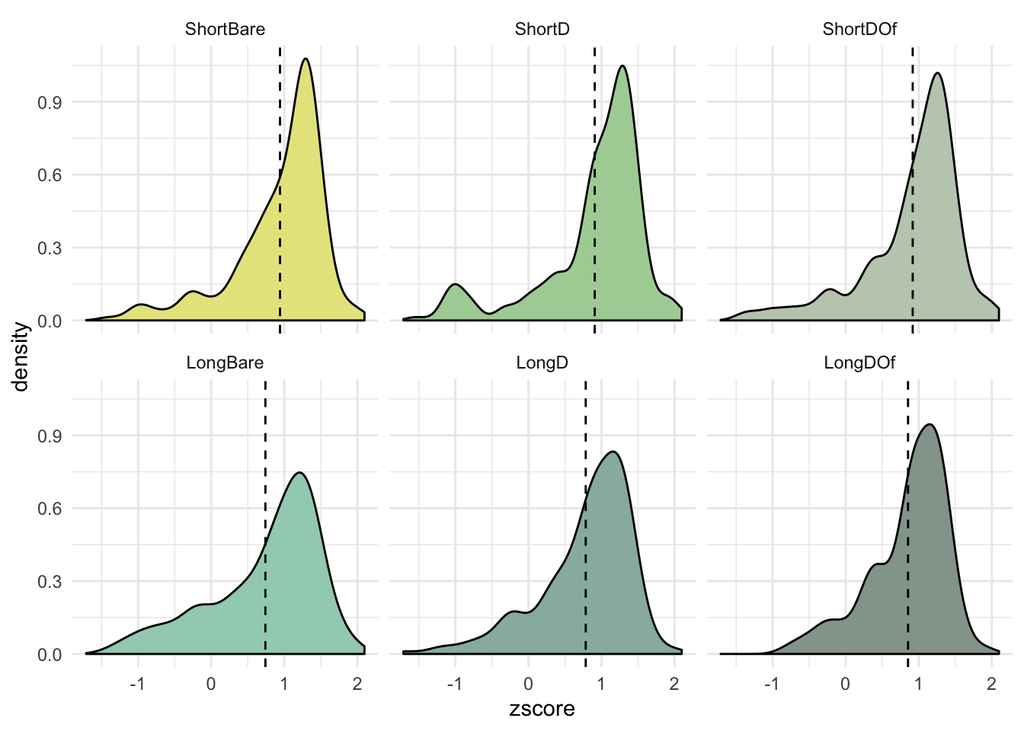

```r
ggplot(df.english.dlink, aes(zscore, fill=condition, group=condition)) +
  scale_fill_ghibli_d("MarnieLight2", -1) +
  geom_density(show.legend=FALSE) +
  theme_minimal() +
  geom_vline(data=(df.english.dlink %>% group_by(condition) %>% summarise(mean = mean(zscore))),
                        aes(xintercept=mean), linetype="dashed", size=0.5) +
  facet_wrap(.~condition)
```

### Fillers

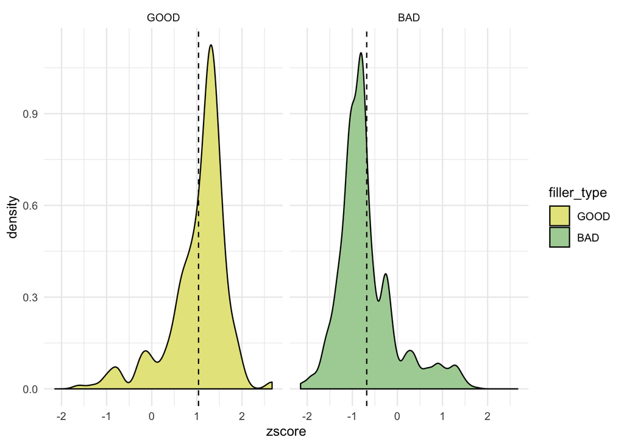

```r
ggplot(df.english.filler, aes(zscore, fill=filler_type)) +
  scale_fill_ghibli_d("MarnieLight2", -1) +
  geom_density() +
  theme_minimal() +
  geom_vline(data=(df.english.filler %>% group_by(filler_type) %>% summarise(mean = mean(zscore))),
                        aes(xintercept=mean), linetype="dashed", size=0.5) +
  facet_wrap(.~filler_type)
```

### Violin + dot plots

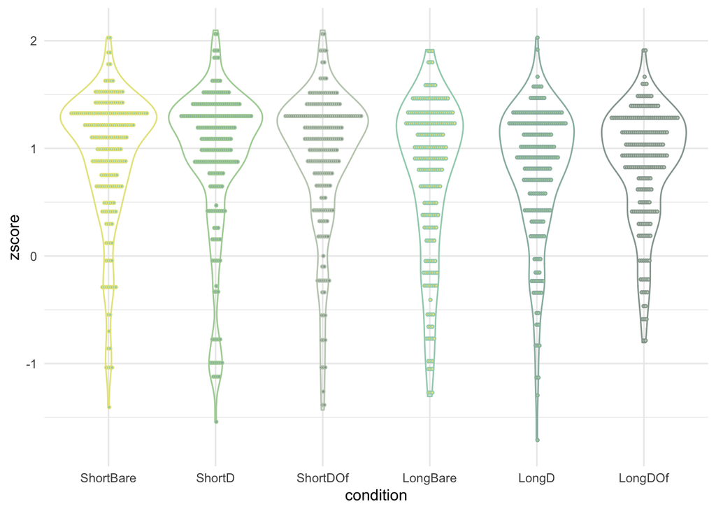

```r
ggplot(df.english.dlink, aes(x=condition, y=zscore, group=condition), show.legend = FALSE) +
  scale_fill_ghibli_d("MarnieLight2", -1) +
  scale_color_ghibli_d("MarnieLight2", -1) +
  theme_minimal() +
  geom_violin(aes(color=condition, fill=NA), show.legend = FALSE) +
  geom_dotplot(binaxis='y', stackdir='center', binwidth=0.1,
               stackratio=0.6, dotsize=0.3, aes(color=condition, fill=condition), show.legend = FALSE)
```

## Planned contrasts

Just for fun, here is contrast coding for running a 2x3 as a 1x6 (to remind myself how to do it). It doesn’t take into account random effects, so it’s not actually the best model for the data. There was a significant main effect of short ($\mu = 0.922$) vs. long ($\mu = 0.793$): sentences with shorter distances between the filler and the gap were more acceptable ($t[1338] = 3.660, CI = [0.179, 0.594], p = 0$).

```r
(0.9415383 + 0.9066709 + 0.9170072) / 3 #MeanShort
```

```
## [1] 0.9217388
```

```r
(0.7415659 + 0.7836209 + 0.8533297) / 3 #MeanLong
```

```
## [1] 0.7928388
```

```r
# Define contrasts
contrasts(df.english.dlink$condition) <- cbind(c(1,1,1,-1,-1,-1), # Short     v. Long
                                               c(1,-1,0,1,-1,0),  # Bare      v. D
                                               c(1,0,-1,1,0,-1),  # Bare      v. DOf
                                               c(1,-1,0,-1,1,0),  # Int1
                                               c(1,0,-1,-1,0,1))  # Int2

# Run ANOVA
dlink.out.aov <- aov(zscore ~ condition, data=df.english.dlink)
summary(dlink.out.aov)
```

```
##               Df Sum Sq Mean Sq F value  Pr(>F)
## condition      5    7.2  1.4308   3.433 0.00436 **
## Residuals   1338  557.6  0.4167
## ---
## Signif. codes:  0 '***' 0.001 '**' 0.01 '*' 0.05 '.' 0.1 ' ' 1
```

```r
# Run contrasts
fit.contrast(dlink.out.aov, "condition",
        rbind("ME1.ShortVLong"        = c(1,1,1,-1,-1,-1),
              "ME2.BarevD"            = c(1,-1,0,1,-1,0),
              "ME3.BarevDOf"          = c(1,0,-1,1,0,-1),
              "Int1.LengthxD"         = c(1,-1,0,-1,1,0),
              "Int2.LengthxDOf"       = c(1,0,-1,-1,0,1)),
        df=T, conf.int=0.95, show.all=TRUE)
```

```
##                              Estimate Std. Error     t value     Pr(>|t|)   DF
## conditionME1.ShortVLong   0.386699878 0.10565453  3.66004077 0.0002619876 1338
## conditionME2.BarevD      -0.007187632 0.08626656 -0.08331886 0.9336104643 1338
## conditionME3.BarevDOf    -0.087232765 0.08626656 -1.01120022 0.3121034353 1338
## conditionInt1.LengthxD    0.076922376 0.08626656  0.89168243 0.3727234945 1338
## conditionInt2.LengthxDOf  0.136294917 0.08626656  1.57992757 0.1143598114 1338
##                             lower CI   upper CI
## conditionME1.ShortVLong   0.17943332 0.59396644
## conditionME2.BarevD      -0.17642007 0.16204481
## conditionME3.BarevDOf    -0.25646520 0.08199967
## conditionInt1.LengthxD   -0.09231006 0.24615481
## conditionInt2.LengthxDOf -0.03293752 0.30552735
## attr(,"class")
## [1] "fit_contrast"
```

## Mixed-effects model

In order to do a proper 2x3, the data must be recoded, so we do that here.

```r
df.english.dlink <- df.english.dlink %>%
  mutate(distance=ifelse(
    condition=="ShortBare" | condition == "ShortD" | condition=="ShortDOf", "Short", "Long"),
    dlink=ifelse(
      condition=="ShortBare" | condition=="LongBare", "Bare",
      ifelse(condition=="ShortD" | condition=="LongD", "D", "DOf")
      ),
    dlinkBin=ifelse(
      condition=="ShortBare" | condition=="LongBare", "Bare", "DLink"
      )
    )

# Create factors
df.english.dlink$distance    <- factor(df.english.dlink$distance, levels=c("Short", "Long"))
df.english.dlink$dlink       <- factor(df.english.dlink$dlink, levels=c("Bare", "D", "DOf"))
df.english.dlink$dlinkBin    <- factor(df.english.dlink$dlinkBin, levels=c("Bare", "DLink"))

# Summaries
df.english.dlink %>% group_by(distance, dlink) %>% summarize(count=n(), mean=mean(zscore), sd=sd(zscore), se=sd / sqrt(count)) %>% ungroup()
```

```
## # A tibble: 6 x 6
##   distance dlink count  mean    sd     se
##   <fct>    <fct> <int> <dbl> <dbl>  <dbl>
## 1 Short    Bare    224 0.942 0.619 0.0413
## 2 Short    D       224 0.907 0.703 0.0470
## 3 Short    DOf     224 0.917 0.650 0.0434
## 4 Long     Bare    224 0.742 0.731 0.0488
## 5 Long     D       224 0.784 0.623 0.0416
## 6 Long     DOf     224 0.853 0.527 0.0352
```

```r
df.english.dlink %>% group_by(distance) %>% summarize(count=n(), mean=mean(zscore), sd=sd(zscore), se=sd / sqrt(count)) %>% ungroup()
```

```
## # A tibble: 2 x 5
##   distance count  mean    sd     se
##   <fct>    <int> <dbl> <dbl>  <dbl>
## 1 Short      672 0.922 0.658 0.0254
## 2 Long       672 0.793 0.633 0.0244
```

```r
df.english.dlink %>% group_by(dlink) %>% summarize(count=n(), mean=mean(zscore), sd=sd(zscore), se=sd / sqrt(count)) %>% ungroup()
```

```
## # A tibble: 3 x 5
##   dlink count  mean    sd     se
##   <fct> <int> <dbl> <dbl>  <dbl>
## 1 Bare    448 0.842 0.684 0.0323
## 2 D       448 0.845 0.667 0.0315
## 3 DOf     448 0.885 0.592 0.0280
```

## Interaction plots

Not much of a difference.

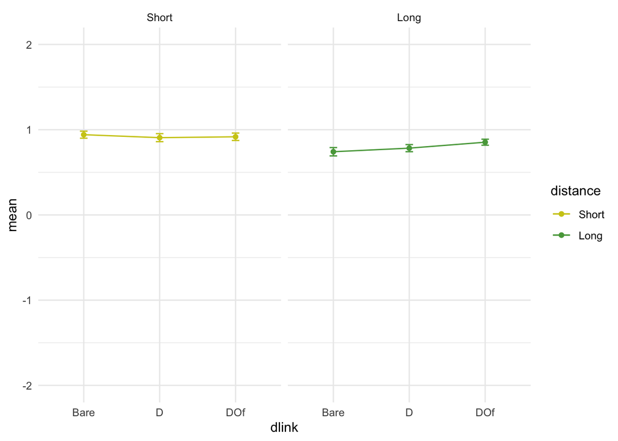

```r
df.english.dlink.summarized <- df.english.dlink %>% group_by(distance, dlink) %>% summarize(count=n(), mean=mean(zscore), sd=sd(zscore), se=sd / sqrt(count)) %>% ungroup()
ggplot(data=df.english.dlink.summarized, aes(x=dlink, y=mean, group=distance, color=distance)) +
  ylim(-2,2) +
  scale_color_ghibli_d("MarnieMedium2", -1) +
  geom_errorbar(aes(ymin=mean-se, ymax=mean+se), width=.1) +
  geom_point() +
  geom_line() +
  theme_minimal() +
  facet_wrap(.~distance)
```

## By-subject plots

I’d do by-item, but the items aren’t labeled such that this is easily possible.

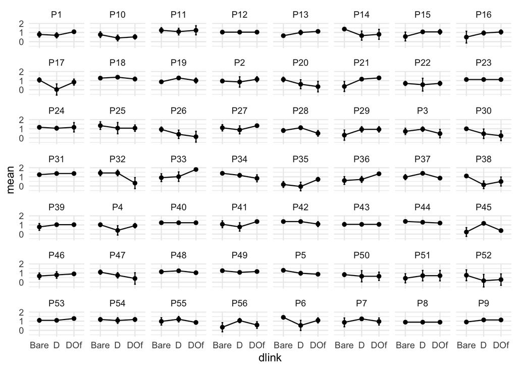

```r
df.english.dlink.summarizedShort <- df.english.dlink %>% filter(distance=="Short") %>% group_by(participant, dlink) %>% summarize(count=n(), mean=mean(zscore), sd=sd(zscore), se=sd / sqrt(count)) %>% ungroup()
ggplot(data=df.english.dlink.summarizedShort, aes(x=dlink, y=mean, group=participant)) +
  geom_errorbar(aes(ymin=mean-se, ymax=mean+se), width=.1) +
  geom_point() +
  geom_line() +
  theme_minimal() +
  facet_wrap(.~participant)
```

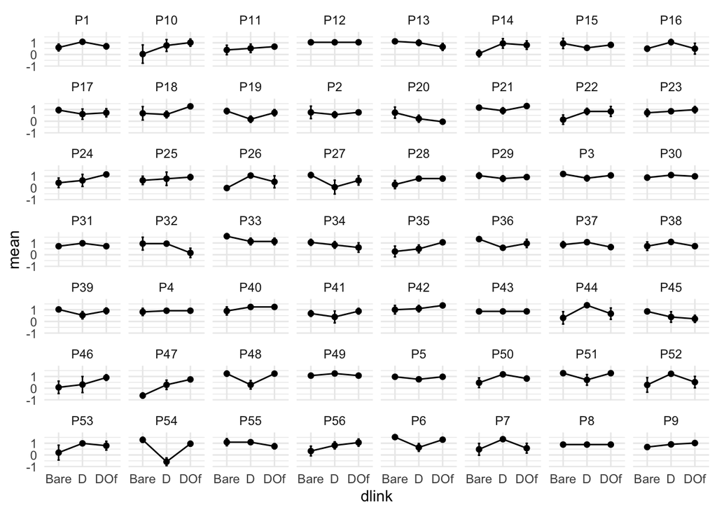

```r
df.english.dlink.summarizedLong <- df.english.dlink %>% filter(distance=="Long") %>% group_by(participant, dlink) %>% summarize(count=n(), mean=mean(zscore), sd=sd(zscore), se=sd / sqrt(count)) %>% ungroup()
ggplot(data=df.english.dlink.summarizedLong, aes(x=dlink, y=mean, group=participant)) +
  geom_errorbar(aes(ymin=mean-se, ymax=mean+se), width=.1) +
  geom_point() +
  geom_line() +
  theme_minimal() +
  facet_wrap(.~participant)
```

## Responses by order

And here are responses in each condition over time. Impressionisically, there is slight improvement in most conditions.

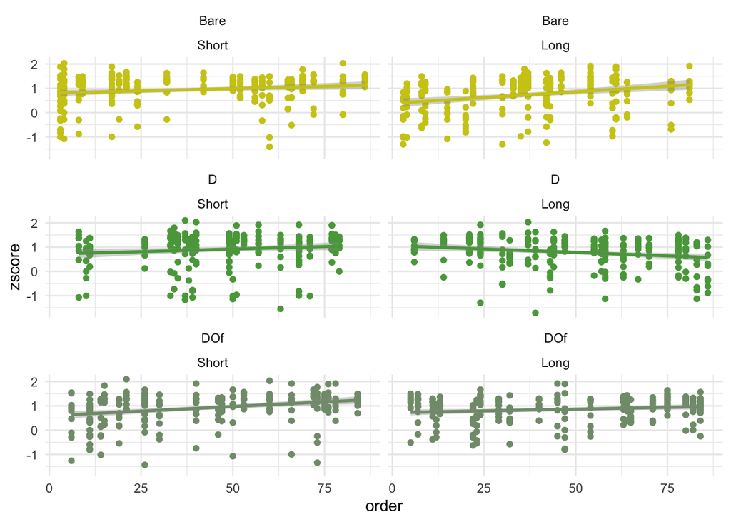

```r
df.english.dlink.posShort <- df.english.dlink %>% filter(distance=="Short") %>% group_by(dlink, order) %>% summarize(count=n(), mean=mean(zscore), sd=sd(zscore), se=sd / sqrt(count)) %>% ungroup()
ggplot(data=df.english.dlink, aes(x=order, y=zscore, color=dlink))  +
    scale_color_ghibli_d("MarnieMedium2", -1) +
  geom_point(show.legend=F) +
  stat_smooth(method="lm", show.legend=F) +
  theme_minimal() +
  facet_wrap(.~dlink*distance, ncol=2)
```

## Mixed-effects model

```r
# Define contrasts
contrasts(df.english.dlink$distance) <- cbind(c(-1, 1))
contrasts(df.english.dlink$dlink)    <- cbind(c(1, -1, 0), c(1, 1, -2))

# Linear mixed-effects

# Note: Can't do by-item intercepts because they're not properly labeled
# Note2: Attempting to include random slopes gives singular fit warning, unclear why

out.lmer <- lmer(zscore ~ distance*dlink + (1 | participant) + (1 | list) + (1 | order), data=df.english.dlink)
summary(out.lmer)
```

```
## Linear mixed model fit by REML. t-tests use Satterthwaite's method [
## lmerModLmerTest]
## Formula: zscore ~ distance * dlink + (1 | participant) + (1 | list) +
##     (1 | order)
##    Data: df.english.dlink
##
## REML criterion at convergence: 2593.1
##
## Scaled residuals:
##     Min      1Q  Median      3Q     Max
## -3.7341 -0.3994  0.2345  0.6406  2.3271
##
## Random effects:
##  Groups      Name        Variance Std.Dev.
##  order       (Intercept) 0.041087 0.20270
##  participant (Intercept) 0.014348 0.11978
##  list        (Intercept) 0.008025 0.08958
##  Residual                0.360487 0.60041
## Number of obs: 1344, groups:  order, 72; participant, 56; list, 6
##
## Fixed effects:
##                    Estimate Std. Error         df t value Pr(>|t|)
## (Intercept)        0.863184   0.049798   7.925569  17.334 1.39e-07 ***
## distance1         -0.066350   0.019538 762.576064  -3.396 0.000719 ***
## dlink1             0.023477   0.025335 541.769169   0.927 0.354518
## dlink2             0.001667   0.014188 681.197933   0.117 0.906530
## distance1:dlink1  -0.042911   0.024987 569.166756  -1.717 0.086458 .
## distance1:dlink2  -0.017032   0.013666 802.073568  -1.246 0.213020
## ---
## Signif. codes:  0 '***' 0.001 '**' 0.01 '*' 0.05 '.' 0.1 ' ' 1
##
## Correlation of Fixed Effects:
##             (Intr) dstnc1 dlink1 dlink2 dst1:1
## distance1   -0.010
## dlink1       0.007  0.036
## dlink2      -0.004 -0.031  0.032
## dstnc1:dln1 -0.011 -0.029 -0.036 -0.006
## dstnc1:dln2  0.022 -0.027  0.014  0.043 -0.011
```